# R Notebook

```r
num_1 <- 33
num_2 <- 200
if (num_2 > num_1){
  print(" num_2 is greater than num_1")
}
```

```
[1] " num_2 is greater than num_1"
```

We do not have the “elif” keyword, it is replaced by using “else if”

```r
num_1 <- num_2
num_1 <-201
if (num_2 > num_1) {
  print (" num_2 is greater than num_1")
} else if (num_1 == num_2) {
  print (" num_1 and num_2 are equal")
} else{
  print (" num_1 is greater than num_2")
  }
```

Indentation is not required in R

Nested ifs

```r
num_1 <- num_2
num_1 <-201
num_2 <-501
if (num_2 > num_1) {
  print (" num_2 is greater than num_1")
  if (num_2 >500){
    print("BALLIN!")
  }
} else if (num_1 == num_2) {
  print (" num_1 and num_2 are equal")
} else{
  print (" num_1 is greater than num_2")
  }
```

WHILE LOOPS

```r
ab <- 1
while(ab < 10){
  print(ab)
  ab <- ab + 1
}
```

Breaks function the same as in Python with the same ‘break’ keyword‘next’ is used in R in place of the ‘continue’ keyword in Python

For loops Function the same as in Python, but with the new bracket syntax:

```r
for (x in 1:100) {
  print(x)
}
cars <- list("Mustang", "Stingray", "The Boss")
for (x in cars) {
  print(x)
  }
```

Functions/Methods Functions are created using the “function” keyword.

```r
my_name <- function(fname = "John", lname = "Doe") {
  paste(fname, lname)
  }
my_name("Joey", "Joe Joe Shabadoo")
```

Return results with the “return” keyword

```r
my_name2 <- function(fname = "John", lname = "Doe") {
  return(paste(fname, lname))
  }
full_name = my_name2("Joey", "Joe Joe Shabadoo")
print(full_name)
```

If you needed, global variables can be set using the following: tempvar <<- 778 Note the double ‘<<’

```r
my_name <- function(fname = "John", lname = "Doe") {
  temp_var1 <<- 1 # <<- is global!!!
  paste(fname, lname)
  print(temp_var1)
  }
my_name("Joey", "Joe Joe Shabadoo")
print(temp_var1)
```

## To install libraries = just paste it in console

Dataframes

library(readxl) Taxes <- read_excel(“~/Downloads/Taxes.xlsx”, sheet = “Sheet2”) View(Taxes)

```r
print(Taxes)
#View(Taxes)
#edit(Taxes)
class(Taxes) #class is type ;shows its dataframe
```

```python
k=1
print(k)
```

dataframes You can access elements in the DF with the following methods:

```r
GHCND_sample_csv[["PRCP"]][3]
```

```
[1] 0
```

```r
GHCND_sample_csv$PRCP[4]
```

```
[1] 15
```

```r
GHCND_sample_csv$PRCP[5]
```

```
[1] 9999
```

Loading CSV without the GUITo load a CSV without the GUI, you can do the following:

fileloc <- “C:\Users\lbd38\Downloads\GHCND_sample_csv2.csv” var_csv <- read.csv(fileloc)

library(readr) GHCND_sample <- read_csv(“~/Desktop/GHCND_sample.csv”) View(GHCND_sample)

```r
#print(GHCND_sample)
#edit(GHCND_sample)
GHCND_sample[["PRCP"]][3]
```

```
[1] 0
```

```r
GHCND_sample$PRCP[4]
```

```
[1] 15
```

```r
GHCND_sample$PRCP[5]
```

```
[1] 9999
```

```r
dim.data.frame(GHCND_sample)
```

```
[1] 31  9
```

DATA FRAME FUNCTIONS

dim() returns the dimensions of the DF

ncol() returns the number of columns in the DF

colnames()/names() returns a vector that contains all the column names

rownames()/row.names() returns a vector that contains all the row names

head() returns the header row and the first 6 rows of data

tail() returns the header row and the last 6 rows of data

```r
headernames <- names(GHCND_sample)
headernames2 <- names(Taxes)
print(headernames)
```

```
[1] "STATION"      "STATION_NAME" "ELEVATION"    "LATITUDE"     "LONGITUDE"    "DATE"         "TMAX"
[8] "TMIN"         "PRCP"
```

```r
print(headernames2)
```

```
 [1] "(A) 1450 E Sample Road #211"   "...2"                          "...3"
 [4] "(B) 1250 E SAMPLE ROAD #306 "  "...5"                          "...6"
 [7] "(C) 1480 E SAMPLE ROAD #307"   "...8"                          "...9"
[10] "(A) 1250 E SAMPLE ROAD #201"   "NEW PURCHASE"                  "...12"
[13] "4311 CRYSTAL LAKE DRIVE #101 " "Homestead"
```

```r
class(headernames2)
```

```
[1] "character"
```

```r
headernames[9]
```

```
[1] "PRCP"
```

```r
head(GHCND_sample)
```

| STATION | STATION_NAME | ELEVATION | LATITUDE | LONGITUDE | DATE | TMAX | TMIN | PRCP |
| --- | --- | --- | --- | --- | --- | --- | --- | --- |
| GHCND:USC00327027 | PETERSBURG 2 N ND US | 466.3 | 48.0355 | -98.01 | 20100101 | -178 | -311 | 0 |
| GHCND:USC00327027 | PETERSBURG 2 N ND US | 466.3 | 48.0355 | -98.01 | 20100102 | -244 | -322 | 0 |
| GHCND:USC00327027 | PETERSBURG 2 N ND US | 466.3 | 48.0355 | -98.01 | 20100103 | -194 | -289 | 0 |
| GHCND:USC00327027 | PETERSBURG 2 N ND US | 466.3 | 48.0355 | -98.01 | 20100104 | -167 | -200 | 15 |
| GHCND:USC00327027 | PETERSBURG 2 N ND US | 466.3 | 48.0355 | -98.01 | 20100105 | -133 | -167 | 9999 |
| GHCND:USC00327027 | PETERSBURG 2 N ND US | 466.3 | 48.0355 | -98.01 | 20100106 | -133 | -172 | 9999 |

```r
tail(GHCND_sample)
```

| STATION | STATION_NAME | ELEVATION | LATITUDE | LONGITUDE | DATE | TMAX | TMIN | PRCP |
| --- | --- | --- | --- | --- | --- | --- | --- | --- |
| GHCND:USC00327027 | PETERSBURG 2 N ND US | 466.3 | 48.0355 | -98.01 | 20100126 | -161 | -233 | 0 |
| GHCND:USC00327027 | PETERSBURG 2 N ND US | 466.3 | 48.0355 | -98.01 | 20100127 | -167 | -222 | 0 |
| GHCND:USC00327027 | PETERSBURG 2 N ND US | 466.3 | 48.0355 | -98.01 | 20100128 | -167 | -283 | 0 |
| GHCND:USC00327027 | PETERSBURG 2 N ND US | 466.3 | 48.0355 | -98.01 | 20100129 | -189 | -283 | 0 |
| GHCND:USC00327027 | PETERSBURG 2 N ND US | 466.3 | 48.0355 | -98.01 | 20100130 | -156 | -267 | 0 |
| GHCND:USC00327027 | PETERSBURG 2 N ND US | 466.3 | 48.0355 | -98.01 | 20100131 | -150 | -272 | 0 |

LISTS! Convert a DF vector to a list

```r
listx <- list(GHCND_sample$LATITUDE)
listy <- list(GHCND_sample$PRCP)

#print(listx)
#print(listy)

listy[[1]][3]
```

```
[1] 0
```

```r
listy[[1]][4]
```

```
[1] 15
```

```r
listy[[1]][5]
```

```
[1] 9999
```

Plotting - scatter

col is color

Change the size of the points by including the ‘cex = x’

attributeChange the point shape with the ‘pch = x’ attribute:

```r
plot(GHCND_sample$DATE,GHCND_sample$TMAX, col = 3, main = "Temps", xlab = "Dates", ylab = "Temps", pch = 10)

points(GHCND_sample$DATE,GHCND_sample$TMIN, col = 2, pch = 7) #points connect other colors to graph
```

[output not shown]

Plotting - line

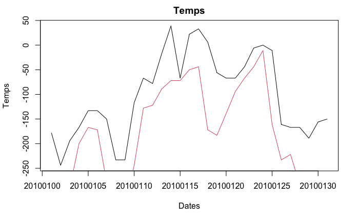

```r
plot(GHCND_sample$DATE,GHCND_sample$TMAX, type = "l", col = 1, main = "Temps", xlab = "Dates", ylab = "Temps")

lines(GHCND_sample$DATE,GHCND_sample$TMIN, type = "l", col = 2)
```

Bar Plots

[figure not shown]

```r
#barplot(GHCND_sample$TMAX, names.arg = GHCND_sample$DATE, col = "red", density = 15, width = c(5,4,3,1))

barplot(GHCND_sample$TMAX, names.arg = GHCND_sample$DATE, col = "red", density = 15, width = c(5,4,3,1), horiz = TRUE)
```

Pie charts

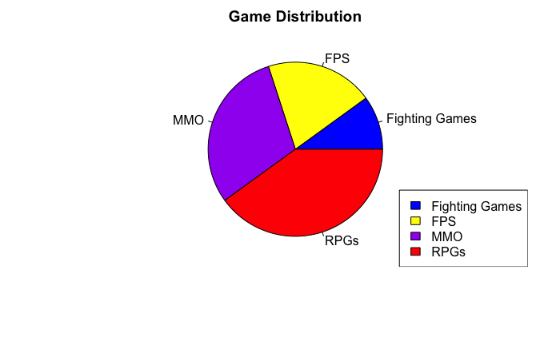

```r
x <- c(10,20,30,40)

mylabel <- c("Fighting Games", "FPS", "MMO", "RPGs")

colors <- c("blue", "yellow", "purple", "red")

pie(x, label = mylabel, main = "Game Distribution", col = colors)

legend("bottomright", mylabel, fill = colors)
```

Statistics with DataFrames and R

The summary() function provides a very quick way of obtaining statistical information about the dataset in the DF.

Summary returns the following information for each variable:

Min - can also use min() function

min(GHCND_sample_csv2$TMAX) •Can be verified with the which.min() function, which returns the index position of the min value.•which.min(GHCND_sample_csv2$TMAX)

First quantile – the value that cuts off the first 25% of dataMedian - can also use the median() function

 median(GHCND_sample_csv2$TMAX)

Mean – can also use the mean() function  mean(GHCND_sample_csv2$TMAX)

Third quantile – the value that cuts off the first 75% of data•use the quantile() function to get the other quartiles.•quantile(GHCND_sample_csv2$TMIN, c(0.50))

Max – can be verified with the which.max() function , which returns the index position of the max value.•The same functions as MIN apply for MAX.

```r
#summary(GHCND_sample)
quantile(GHCND_sample$TMIN)
```

```
    0%    25%    50%    75%   100%
-328.0 -275.0 -172.0  -91.5  -11.0
```

```r
quantile(GHCND_sample$TMIN, c(0.50))
```

```
 50%
-172
```

```r
#data()
library(MASS)
data()
```